# **1. Delay Patterns:**

**📁 Step 1: Data Preparation in HDFS**

- The raw CSV file airline_2008.csv was uploaded from the host system into the HDFS path:

```
/user/maria_dev/afiqah/assignment/airline_2008.csv
```

File verification using PUTTY:

```
hdfs dfs -ls /user/maria_dev/afiqah/assignment/
```

----important notes : make sure csv folder that you want to get from hdfs to hive is a single file in that folder

**🐝 Step 2: Create External Table in Hive**

- A Hive external table was created to interface with the CSV data in Ambari :

```
DROP TABLE IF EXISTS airline_2006_ext;


CREATE EXTERNAL TABLE airline_2006_ext (
  Year INT,
  Month INT,
  DayofMonth INT,
  DayOfWeek INT,
  DepTime INT,
  CRSDepTime INT,
  ArrTime INT,
  CRSArrTime INT,
  UniqueCarrier STRING,
  FlightNum STRING,
  TailNum STRING,
  ActualElapsedTime INT,
  CRSElapsedTime INT,
  AirTime INT,
  ArrDelay INT,
  DepDelay INT,
  Origin STRING,
  Dest STRING,
  Distance INT,
  TaxiIn INT,
  TaxiOut INT,
  Cancelled INT,
  CancellationCode STRING,
  Diverted INT,
  CarrierDelay INT,
  WeatherDelay INT,
  NASDelay INT,
  SecurityDelay INT,
  LateAircraftDelay INT
)
ROW FORMAT DELIMITED
FIELDS TERMINATED BY ','
STORED AS TEXTFILE
LOCATION '/user/maria_dev/afiqah/';
```

## **Q1.1 : What times of day (morning/afternoon/evening) have the lowest average delays?**

worksheet 1

```
DROP TABLE IF EXISTS delay_season_day;
CREATE TABLE q1_delay_season_day
ROW FORMAT DELIMITED
FIELDS TERMINATED BY ','
STORED AS TEXTFILE
AS
SELECT Month, CRSDepTime, ArrDelay
FROM airline_2006_ext
WHERE Month IS NOT NULL AND CRSDepTime IS NOT NULL AND ArrDelay IS NOT NULL;
```

💾 Step 4: Download from HDFS to Local Sandbox (Linux)

- Fetched all partitioned output files:

```
hdfs dfs -getmerge /user/maria_dev/afiqah/output_delay_season_day delay_season_day.csv
```

📌 3. Guna WinSCP untuk tarik fail tu ke PC

- Buka WinSCP
- Navigate to: /home/maria_dev/afiqah
- Download delay_season_day.csv ke PC

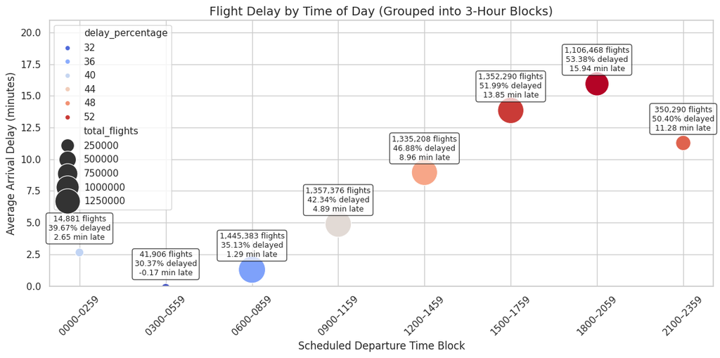

```python
column_names = ['Month', 'CRSDepTime', 'ArrDelay']
q1_daytime = pd.read_csv('/content/q1_delay_season_day.csv', header=None, names=column_names)
q1_daytime['CRSDepTime'] = q1_daytime['CRSDepTime'].astype(int)
q1_daytime['ArrDelay'] = q1_daytime['ArrDelay'].astype(int)

def time_bin(deptime):
    if 0 <= deptime < 300:
        return '0000–0259'
    elif 300 <= deptime < 600:
        return '0300–0559'
    elif 600 <= deptime < 900:
        return '0600–0859'
    elif 900 <= deptime < 1200:
        return '0900–1159'
    elif 1200 <= deptime < 1500:
        return '1200–1459'
    elif 1500 <= deptime < 1800:
        return '1500–1759'
    elif 1800 <= deptime < 2100:
        return '1800–2059'
    else:
        return '2100–2359'
q1_daytime['TimeBlock'] = q1_daytime['CRSDepTime'].apply(time_bin)

summary = q1_daytime.groupby('TimeBlock').agg(
    total_flights=('ArrDelay', 'count'),
    avg_arrival_delay=('ArrDelay', 'mean'),
    delayed_flights=('ArrDelay', lambda x: (x > 0).sum())
).reset_index()
summary['delay_percentage'] = (summary['delayed_flights'] / summary['total_flights']) * 100

# Plot
plt.figure(figsize=(12, 6))
sns.set(style="whitegrid")
ax = sns.scatterplot(
    data=summary,
    x='TimeBlock',
    y='avg_arrival_delay',
    size='total_flights',
    hue='delay_percentage',
    sizes=(100, 1000),
    palette='coolwarm',
    legend='brief'
)
plt.title('Flight Delay by Time of Day (Grouped into 3-Hour Blocks)', fontsize=14)
plt.xlabel('Scheduled Departure Time Block', fontsize=12)
plt.ylabel('Average Arrival Delay (minutes)', fontsize=12)
plt.xticks(rotation=45)

max_avg_delay = summary['avg_arrival_delay'].max()
ax.set_ylim(0, max_avg_delay + 5) # Adjust the 5 to increase or decrease the space

for i, row in summary.iterrows():
    label = (
        f"{row['total_flights']:,} flights\n"
        f"{row['delay_percentage']:.2f}% delayed\n"
        f"{row['avg_arrival_delay']:.2f} min late"
    )
    plt.text(
        x=row['TimeBlock'],
        y=row['avg_arrival_delay'] + 1,
        s=label,
        ha='center',
        fontsize=9,
        bbox=dict(boxstyle='round,pad=0.3', facecolor='white', edgecolor='black', alpha=0.7)
    )
plt.tight_layout()
plt.show()
```

However, delays began to increase steadily as the day moved into late morning and early afternoon, particularly between 9 am and 3 pm. During this period, average delays rose sharply, suggesting increasing pressure on airport systems and tighter scheduling windows. The late afternoon and evening blocks—especially from 3 pm to 9 pm—stood out with the highest average arrival delays, often exceeding 13 to 15 minutes, and more than half of flights in these blocks experienced delays.

This pattern suggests that early scheduled flights are less affected by congestion or chain reaction delays from earlier flights. In contrast, flights in the second half of the day are more vulnerable to operational disruptions, leading to longer delays and higher delay rates.

## **Q1.2 : Which days of the week show better on-time performance?**

This Hive query gets the needed fields:

```
DROP TABLE IF EXISTS q1_ontime_day;

CREATE TABLE q1_ontime_day
ROW FORMAT DELIMITED
FIELDS TERMINATED BY ','
STORED AS TEXTFILE
AS
SELECT DayOfWeek, ArrDelay
FROM airline_2006_ext
WHERE DayOfWeek IS NOT NULL AND ArrDelay IS NOT NULL;
```

Export to HDFS (overwrite directory):

```
hive -e "
INSERT OVERWRITE DIRECTORY '/user/maria_dev/afiqah/output_q1_ontime_day'
ROW FORMAT DELIMITED
FIELDS TERMINATED BY ','
SELECT * FROM q1_ontime_day;"
```

Merge into local CSV:

```
 hdfs dfs -getmerge /user/maria_dev/afiqah/output_q1_2_ontime_day q1_2_ontime_day.csv
```

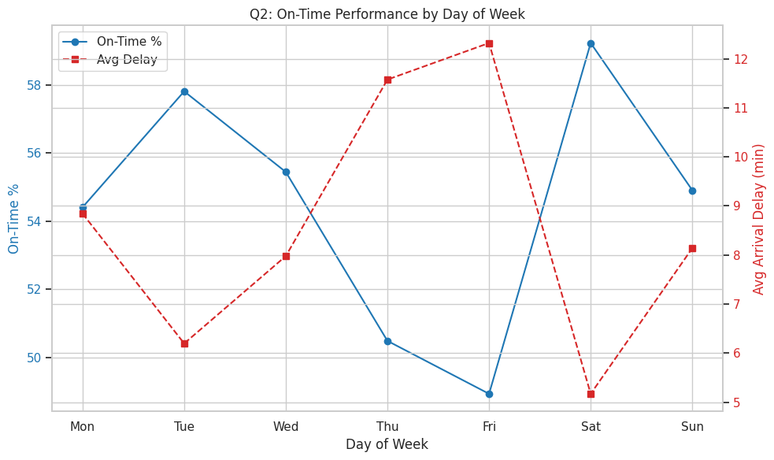

```python
column_names = ['DayOfWeek', 'ArrDelay']
q1_ontime = pd.read_csv('/content/q1_2_ontime_day.csv', header=None, names=column_names)
q1_ontime.dropna(inplace=True)
q1_ontime['DayOfWeek'] = q1_ontime['DayOfWeek'].astype(int)
q1_ontime['ArrDelay'] = q1_ontime['ArrDelay'].astype(int)

# Group by day
summary = q1_ontime.groupby('DayOfWeek').agg(
    total_flights=('ArrDelay', 'count'),
    avg_delay=('ArrDelay', 'mean'),
    on_time_flights=('ArrDelay', lambda x: (x <= 0).sum())
).reset_index()
summary['on_time_percentage'] = (summary['on_time_flights'] / summary['total_flights']) * 100

# Set up plot
sns.set(style='whitegrid')
fig, ax1 = plt.subplots(figsize=(10, 6))

# Line 1 - On-time %
color1 = 'tab:blue'
ax1.set_xlabel('Day of Week')
ax1.set_ylabel('On-Time %', color=color1)
l1, = ax1.plot(summary['DayOfWeek'], summary['on_time_percentage'], color=color1, marker='o', label='On-Time %')
ax1.tick_params(axis='y', labelcolor=color1)
ax1.set_xticks(range(1, 8))
ax1.set_xticklabels(['Mon', 'Tue', 'Wed', 'Thu', 'Fri', 'Sat', 'Sun'])

# Line 2 - Avg Delay
ax2 = ax1.twinx()
color2 = 'tab:red'
ax2.set_ylabel('Avg Arrival Delay (min)', color=color2)
l2, = ax2.plot(summary['DayOfWeek'], summary['avg_delay'], color=color2, marker='s', linestyle='--', label='Avg Delay')
ax2.tick_params(axis='y', labelcolor=color2)

# Combine legends
lines = [l1, l2]
labels = [line.get_label() for line in lines]
ax1.legend(lines, labels, loc='upper left')

# Title & layout
plt.title('Q2: On-Time Performance by Day of Week')
fig.tight_layout()
plt.show()
```

On the other hand, weekdays, especially Thursday and Friday, show poorer performance. The blue line dips sharply on those two days, while the red line spikes, indicating delays are both more frequent and more severe. Friday has the highest average delay of over 12 minutes, and its on-time percentage is one of the lowest. Monday and Tuesday are somewhere in the middle, with Tuesday slightly outperforming Monday.

This pattern could reflect lower air traffic and smoother operations during weekends, while weekdays are busier with more congestion and higher chances of delays

## Q1.3 : During which months or seasons are flights most likely to be on time?

```
DROP TABLE IF EXISTS q3_month_table_2006;

CREATE TABLE q3_month_table_2006
ROW FORMAT DELIMITED
FIELDS TERMINATED BY ','
STORED AS TEXTFILE
AS
SELECT
  Month,
  ArrDelay
FROM airline_2006_ext
WHERE Month IS NOT NULL AND ArrDelay IS NOT NULL;
```

then in Putty

```
hdfs dfs -get /apps/hive/warehouse/q3_month_table_2006/* ~/
cat 000000_0 > q3_month_data_2006.csv
```

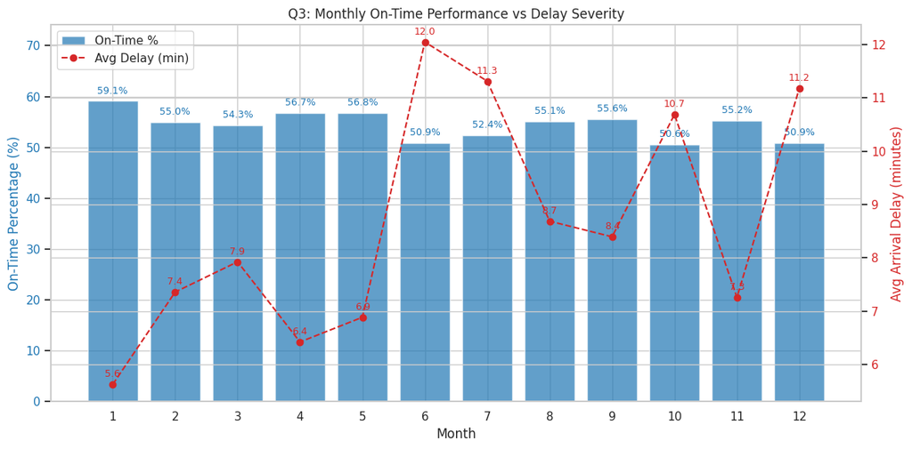

```python
q3_month = pd.read_csv('/content/q3_month_data_2006.csv', sep='\x01', header=None, names=['Month', 'ArrDelay'])
q3_month.dropna(inplace=True)
q3_month = q3_month[q3_month['Month'].between(1, 12)]
q3_month['ArrDelay'] = q3_month['ArrDelay'].astype(int)

# Group summary
summary = q3_month.groupby('Month').agg(
    total_flights=('ArrDelay', 'count'),
    avg_delay=('ArrDelay', 'mean'),
    on_time_flights=('ArrDelay', lambda x: (x <= 0).sum())
).reset_index()
summary['on_time_percentage'] = (summary['on_time_flights'] / summary['total_flights']) * 100

# Plotting
sns.set(style='whitegrid')
fig, ax1 = plt.subplots(figsize=(12, 6))

color = 'tab:blue'
bars = ax1.bar(summary['Month'], summary['on_time_percentage'], color=color, alpha=0.7, label='On-Time %')

# Auto adjust y-limit to add space above tallest bar
max_y = summary['on_time_percentage'].max()
ax1.set_ylim(0, max_y + 15)  # Tambah 10% buffer atas

ax1.set_xlabel('Month')
ax1.set_ylabel('On-Time Percentage (%)', color=color)
ax1.tick_params(axis='y', labelcolor=color)
ax1.set_xticks(range(1, 13))
ax1.set_title('Q3: Monthly On-Time Performance vs Delay Severity')

for bar in bars:
    height = bar.get_height()
    ax1.annotate(f'{height:.1f}%',
                 xy=(bar.get_x() + bar.get_width() / 2, height),
                 xytext=(0, 5),
                 textcoords="offset points",
                 ha='center', va='bottom', fontsize=9, color=color)

ax2 = ax1.twinx()
color2 = 'tab:red'
line = ax2.plot(summary['Month'], summary['avg_delay'], color=color2, marker='o', label='Avg Delay (min)', linestyle='--')
ax2.set_ylabel('Avg Arrival Delay (minutes)', color=color2)
ax2.tick_params(axis='y', labelcolor=color2)

for i, row in summary.iterrows():
    ax2.annotate(f"{row['avg_delay']:.1f}",
                 xy=(row['Month'], row['avg_delay']),
                 xytext=(0, 5),
                 textcoords='offset points',
                 ha='center', va='bottom', fontsize=9, color=color2)

lines_1, labels_1 = ax1.get_legend_handles_labels()
lines_2, labels_2 = ax2.get_legend_handles_labels()
ax1.legend(lines_1 + lines_2, labels_1 + labels_2, loc='upper left')

plt.tight_layout()
plt.show()
```

Based on the plot, we can see the pattern between the percentage of on time flights and the average delay. When more flights arrive on time, the average delay tends to be lower, and when fewer flights are on time, delays are longer. For instance, April and May show one of the better combinations with on time rates above 56 percent and average delays under 7 minutes. September follows a similar pattern, staying above 55 percent with delay minutes staying moderate. These months seem to offer smoother operations, likely due to milder weather and less travel congestion.

In contrast, June, July, and December show weaker performance. On time percentages drop close to 50 percent while delay minutes rise sharply, especially in June where delays go beyond 12 minutes. December also sees a dip in punctuality along with increased delay minutes. These months correspond with peak travel seasons such as school holidays and year end festive periods, where airports are more crowded and weather is less predictable.

# **2. Delay Factors**

- Identify and rank the top 3-5 factors contributing to flight delays, based on the delay categories provided in the dataset.
- Quantify the impact of each factor (in minutes of delay and percentage of total delays).

## 2.1 Identify and rank the top 3-5 factors contributing to flight delays, based on the delay categories provided in the dataset.

hive:

```
DROP TABLE IF EXISTS q2_flight_delays;

CREATE TABLE q2_flight_delays
ROW FORMAT DELIMITED
FIELDS TERMINATED BY ','
STORED AS TEXTFILE
AS
SELECT
  CarrierDelay,
  WeatherDelay,
  NASDelay,
  SecurityDelay,
  LateAircraftDelay
FROM airline_2006_ext
WHERE CarrierDelay IS NOT NULL
  AND WeatherDelay IS NOT NULL
  AND NASDelay IS NOT NULL
  AND SecurityDelay IS NOT NULL
  AND LateAircraftDelay IS NOT NULL;
```

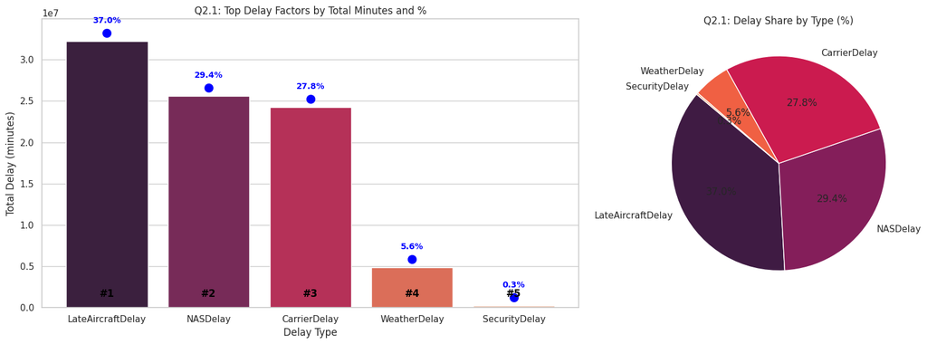

```python
columns = ['CarrierDelay', 'WeatherDelay', 'NASDelay', 'SecurityDelay', 'LateAircraftDelay']
q21_flight_delays = pd.read_csv('/content/q21_flight_delays.csv', header=None, names=columns)

q21_flight_delays = q21_flight_delays.apply(pd.to_numeric, errors='coerce')
q21_flight_delays.dropna(how='all', inplace=True)

total_delays = q21_flight_delays.sum()
delay_summary = pd.DataFrame({
    'DelayType': total_delays.index,
    'TotalDelayMinutes': total_delays.values
})
total_all = delay_summary['TotalDelayMinutes'].sum()
delay_summary['Percentage'] = (delay_summary['TotalDelayMinutes'] / total_all) * 100

delay_summary = delay_summary.sort_values(by='TotalDelayMinutes', ascending=False).reset_index(drop=True)

palette = sns.color_palette('rocket', len(delay_summary))
fig, (ax1, ax2) = plt.subplots(1, 2, figsize=(16, 6), gridspec_kw={'width_ratios': [2, 1]})
sns.set(style='whitegrid')

sns.barplot(
    x='DelayType',
    y='TotalDelayMinutes',
    data=delay_summary,
    hue='DelayType', # Assign x to hue
    palette=palette,
    ax=ax1,
    legend=False # Set legend to False
)
for i, row in delay_summary.iterrows():
    ax1.scatter(i, row['TotalDelayMinutes'] + 1e6, color='blue', s=100)
    ax1.text(i, row['TotalDelayMinutes'] + 2e6,
             f"{row['Percentage']:.1f}%", ha='center', va='bottom',
             fontsize=10, fontweight='bold', color='blue')
    ax1.text(i, 1e6, f"#{i+1}", ha='center', va='bottom',
             fontsize=12, fontweight='bold', color='black')

ax1.set_title('Q2.1: Top Delay Factors by Total Minutes and %')
ax1.set_xlabel('Delay Type')
ax1.set_ylabel('Total Delay (minutes)')

ax2.pie(
    delay_summary['TotalDelayMinutes'],
    labels=delay_summary['DelayType'],
    autopct='%1.1f%%',
    startangle=140,
    colors=palette
)
ax2.set_title('Q2.1: Delay Share by Type (%)')
plt.tight_layout()
plt.show()
```

Based on the plots, three delay factors stand out compared to the rest. Late aircraft delay is the biggest contributor, shown by the tallest bar and the largest slice in the pie chart. It accounts for more than a third of all delay minutes, which suggests that when an incoming flight is late, it often causes a chain reaction of delays for the next flights scheduled with the same aircraft.

NAS delay, which includes things like air traffic control and airport congestion, comes second. Its bar is slightly shorter than the late aircraft delay but still significantly higher than the rest. This shows that airspace management and airport system delays are also major contributors.

Carrier delay ranks third and is only slightly lower than NAS delay. This usually includes delays caused by the airline itself, such as crew issues or maintenance.

Weather and security delays are visibly much smaller on both the bar chart and pie chart. While still important, they contribute far less overall compared to the top three.

```python
print("Summary of Total Flight Delays by Type (in minutes and %):\n")
for i, row in delay_summary.iterrows():
    print(f"{i+1}. {row['DelayType']}: {row['TotalDelayMinutes']:,} minutes "
          f"({row['Percentage']:.2f}%)")
```

```
Summary of Total Flight Delays by Type (in minutes and %):

1. LateAircraftDelay: 32,245,816 minutes (36.98%)
2. NASDelay: 25,610,715 minutes (29.37%)
3. CarrierDelay: 24,255,294 minutes (27.82%)
4. WeatherDelay: 4,853,843 minutes (5.57%)
5. SecurityDelay: 221,371 minutes (0.25%)
```

## 2.2 Quantify the impact of each factor (in minutes of delay and percentage of total delays).

```python
import pandas as pd

columns = ['CarrierDelay', 'WeatherDelay', 'NASDelay', 'SecurityDelay', 'LateAircraftDelay']
q21_flight_delays = pd.read_csv('/content/q21_flight_delays.csv', header=None, names=columns)

q21_flight_delays = q21_flight_delays.apply(pd.to_numeric, errors='coerce')

q21_flight_delays.dropna(how='all', inplace=True)
total_delays = q21_flight_delays.sum()

delay_summary = pd.DataFrame({
    'DelayType': total_delays.index,
    'TotalDelayMinutes': total_delays.values
})
total_all = delay_summary['TotalDelayMinutes'].sum()
delay_summary['Percentage'] = (delay_summary['TotalDelayMinutes'] / total_all) * 100
```

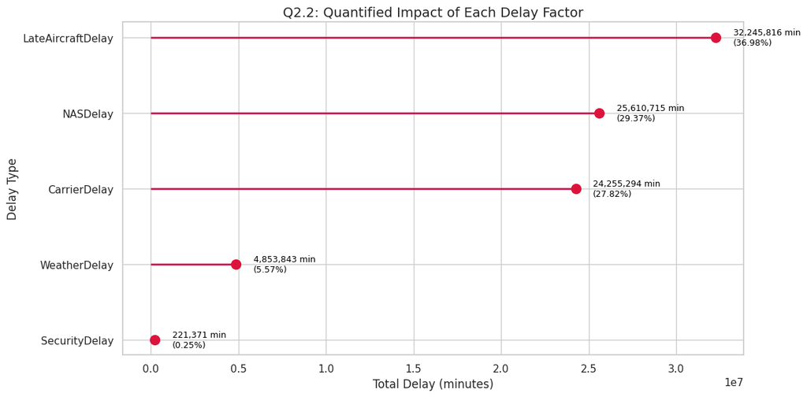

```python
q22_data = pd.DataFrame({
    'DelayType': ['LateAircraftDelay', 'NASDelay', 'CarrierDelay', 'WeatherDelay', 'SecurityDelay'],
    'TotalDelayMinutes': [32245816, 25610715, 24255294, 4853843, 221371],
})
q22_data['Percentage'] = (q22_data['TotalDelayMinutes'] / q22_data['TotalDelayMinutes'].sum()) * 100

q22_data = q22_data.sort_values(by='TotalDelayMinutes', ascending=True)

rocket_palette = sns.color_palette("rocket", n_colors=5)
blue_line_color = rocket_palette[2]  # pick the middle tone which is usually blue-ish
plt.figure(figsize=(12, 6))
sns.set(style='whitegrid')

plt.hlines(y=q22_data['DelayType'], xmin=0, xmax=q22_data['TotalDelayMinutes'], color=blue_line_color, linewidth=2)
plt.plot(q22_data['TotalDelayMinutes'], q22_data['DelayType'], 'o', markersize=10, color='crimson')

for i, row in q22_data.iterrows():
    plt.text(row['TotalDelayMinutes'] + 1e6, row['DelayType'],
             f"{int(row['TotalDelayMinutes']):,} min\n({row['Percentage']:.2f}%)",
             va='center', fontsize=9, color='black')

plt.title('Q2.2: Quantified Impact of Each Delay Factor', fontsize=14)
plt.xlabel('Total Delay (minutes)')
plt.ylabel('Delay Type')
plt.tight_layout()
plt.show()
```

The lollipop stems shows that the biggest contributor to total flight delay is Late Aircraft Delay, with over 32 million minutes, making up about 37 percent of all delays. This usually happens when earlier flights arrive late and cause a chain reaction to the next flights.

The second highest is NAS Delay (National Airspace System), which includes things like air traffic control issues or airport congestion. It contributes around 25.6 million minutes, or 29 percent of total delays.

Carrier Delay follows closely behind at 24.2 million minutes, about 28 percent of delays. These are delays caused by the airline itself, such as maintenance, crew issues, or baggage problems.

Weather Delay accounts for just 4.8 million minutes, or roughly 6 percent, showing it’s not as dominant as people often think.

Security Delay has the smallest impact overall, contributing only 221 thousand minutes, less than 1 percent of total delays.

# **3. Cancellation Analysis**

- Identify the primary reasons for flight cancellations as categorized in the dataset.
- Determine if cancellations correlate with specific airlines, airports, or time periods.

in hive view :

```
DROP TABLE IF EXISTS q32_clean;

CREATE TABLE q32_clean
ROW FORMAT DELIMITED
FIELDS TERMINATED BY ','
STORED AS TEXTFILE
AS
SELECT
  CAST(month AS INT),
  CAST(cancelled AS INT),
  UPPER(TRIM(cancellationcode)),
  UPPER(TRIM(uniquecarrier)),
  UPPER(TRIM(origin)),
  UPPER(TRIM(dest))
FROM airline_2006_ext
WHERE
  month IS NOT NULL AND
  cancelled IS NOT NULL AND
  UPPER(TRIM(uniquecarrier)) NOT IN ('', 'UNIQUECARRIER') AND
  UPPER(TRIM(origin)) NOT IN ('', 'ORIGIN') AND
  UPPER(TRIM(dest)) NOT IN ('', 'DEST') AND
  (cancellationcode IS NULL OR cancellationcode IN ('A', 'B', 'C', 'D'));
```

## 3.1 Identify the primary reasons for flight cancellations as categorized in the dataset.

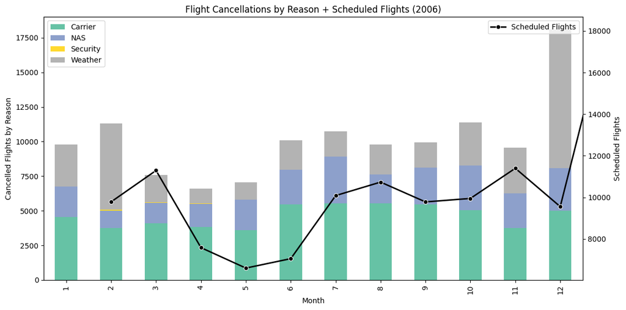

```python
df = pd.read_csv('/content/output_q3_cancellations.csv', header=None, names=['Month', 'Cancelled', 'CancellationCode'])
df.dropna(inplace=True)

df['CancellationReason'] = df['CancellationCode'].map({
    'A': 'Carrier',
    'B': 'Weather',
    'C': 'NAS',
    'D': 'Security'
})

cancelled = df[df['Cancelled'] == 1]

# Group by month & cancellation reason
cancel_reasons = cancelled.groupby(['Month', 'CancellationReason']).size().unstack(fill_value=0)

# 12 months
cancel_reasons = cancel_reasons.reindex(range(1, 13), fill_value=0)

# plot
fig, ax1 = plt.subplots(figsize=(12,6))

# stacked bar
cancel_reasons.plot(kind='bar', stacked=True, ax=ax1, colormap='Set2')

# line chart
ax2 = ax1.twinx()
sns.lineplot(data=monthly_summary, x='Month', y='TotalFlights', ax=ax2,
             label='Scheduled Flights', color='black', linewidth=2, marker='o')
# labels & chart
ax1.set_xlabel('Month')
ax1.set_ylabel('Cancelled Flights by Reason')
ax2.set_ylabel('Scheduled Flights')
plt.title('Flight Cancellations by Reason + Scheduled Flights (2006)')
ax1.legend(loc='upper left')
ax2.legend(loc='upper right')

plt.tight_layout()
plt.show()
```

NAS issues related to air traffic appear in purple and are spread fairly evenly. Security cancellations are extremely low and barely show up.

Overall, carrier issues are the most common reason. Weather is serious in some months, NAS stays steady, and security has little impact.

## 3.2 Determine if cancellations correlate with specific airlines, airports, or time periods

```
DROP TABLE IF EXISTS q32_clean_cancellations;

CREATE TABLE q32_clean_cancellations
ROW FORMAT DELIMITED
FIELDS TERMINATED BY ','
STORED AS TEXTFILE
AS
SELECT
  CAST(month AS INT) AS month,
  CAST(cancelled AS INT) AS cancelled,
  UPPER(TRIM(cancellationcode)) AS cancellationcode,
  UPPER(TRIM(uniquecarrier)) AS uniquecarrier,
  UPPER(TRIM(origin)) AS origin,
  UPPER(TRIM(dest)) AS dest
FROM airline_2006_ext
WHERE
  month IS NOT NULL AND
  cancelled IS NOT NULL AND
  UPPER(TRIM(uniquecarrier)) NOT IN ('', 'UNIQUECARRIER') AND
  UPPER(TRIM(origin)) NOT IN ('', 'ORIGIN') AND
  UPPER(TRIM(dest)) NOT IN ('', 'DEST') AND
  (cancellationcode IS NULL OR cancellationcode IN ('A', 'B', 'C', 'D'));
```

```python
import plotly.graph_objects as go
from plotly.subplots import make_subplots
import plotly.express as px


df = pd.read_csv('/content/q32_clean.csv', header=None,names=['Month', 'Cancelled', 'CancellationCode', 'Carrier', 'Origin', 'Dest'])

cancelled = df[df['Cancelled'] == 1].copy()

airline_hubs = {
    'AA': 'DFW', 'DL': 'ATL', 'UA': 'ORD', 'WN': 'DAL',
    'AS': 'SEA', 'B6': 'JFK', 'F9': 'DEN', 'NK': 'FLL',
    'YV': 'PHX', 'OH': 'CVG', 'OO': 'SLC', 'EV': 'IAH',
    'TZ': 'MDW', 'XE': 'IAH'
}
cancelled['HubAirport'] = cancelled['Carrier'].map(airline_hubs)

# Step 3: Add season info
def get_season(month):
    if month in [12, 1, 2]:
        return 'Winter'
    elif month in [3, 4, 5]:
        return 'Spring'
    elif month in [6, 7, 8]:
        return 'Summer'
    else:
        return 'Autumn'
cancelled['Season'] = cancelled['Month'].apply(get_season)

# Step 4: Load airport coordinates
airports = pd.read_csv('/content/airports.csv')  # Downloaded from ourairports.com
airports = airports[['iata_code', 'latitude_deg', 'longitude_deg']].dropna()
airports.columns = ['HubAirport', 'lat', 'lon']

# Step 5: Prepare map data
hub_counts = cancelled.groupby('HubAirport').size().reset_index(name='CancellationCount')
hub_counts = hub_counts.dropna(subset=['HubAirport'])
map_data = pd.merge(hub_counts, airports, on='HubAirport', how='left').dropna()

# Step 6: Prepare stacked bar data
pivot_data = cancelled.groupby(['Season', 'HubAirport']).size().reset_index(name='Count')
pivot_data = pivot_data.pivot(index='Season', columns='HubAirport', values='Count').fillna(0)
season_order = ['Winter', 'Spring', 'Summer', 'Autumn']
pivot_data = pivot_data.reindex(season_order)

# Define Set3 color palette (from Plotly)
set3_colors = px.colors.qualitative.Set2 #warna tukar kat sini
hub_airports = pivot_data.columns.tolist()
color_map = {hub: set3_colors[i % len(set3_colors)] for i, hub in enumerate(hub_airports)}

# Step 7: Create subplot
fig = make_subplots(rows=1, cols=2, column_widths=[0.6, 0.4],
                    specs=[[{"type": "scattergeo"}, {"type": "bar"}]],
                    subplot_titles=["Flight Cancellations by Hub Airport", "Seasonal Cancellations by Hub (Stacked)"])
# Map (left)
for i, row in map_data.iterrows():
    fig.add_trace(
        go.Scattergeo(
            lon=[row['lon']],
            lat=[row['lat']],
            text=f"{row['HubAirport']} ({row['CancellationCount']})",
            marker=dict(
                size=12,
                color=color_map.get(row['HubAirport'], 'grey'),
                line=dict(width=0.6, color='black')
            ),
            mode='markers+text',
            textposition='top center',
            showlegend=False
        ),
        row=1, col=1
    )
# Stacked Bar (right)
for hub in hub_airports:
    fig.add_trace(
        go.Bar(
            x=pivot_data.index,
            y=pivot_data[hub],
            name=hub,
            marker_color=color_map[hub]
        ),
        row=1, col=2
    )
# Layout
fig.update_layout(
    barmode='stack',
    height=650,
    title_text="Flight Cancellations: Map by Hub & Seasonal Stack",
    title_x=0.5,
    geo=dict(
        scope='usa',
        showland=True,
        landcolor='lightgrey',
        projection_type='albers usa',
        lataxis=dict(range=[20, 55]),
        lonaxis=dict(range=[-130, -60])
    ),
    margin=dict(l=40, r=40, t=60, b=40)
)
fig.show()
```

[interactive chart not shown]

From both map and stacked bar, flight cancellations are not randomly distributed — they do correlate with certain hub airports and specific times of the year.

For starters, airports like IAH (Houston) and SLC (Salt Lake City) stand out with the highest number of cancellations overall. On the map, these hubs have more vibrant markers, which means they experience way more disruptions compared to others. If we consider the airlines, this makes sense, both IAH and SLC are major hubs for regional carriers like EV, OO, and XE, which operate lots of short-haul flights. These kinds of flights are more prone to cancellation due to tighter schedules and higher weather sensitivity.

Seasonally, Winter shows up as the worst time for cancellations across almost all hubs, which again makes sense considering weather conditions like snowstorms and freezing temps that can really mess up airport operations. IAH, even though it's in Texas, still records a high number of cancellations in winter. That could be due to system-wide delays, or maybe it’s a transfer hub that gets affected when other connected airports face bad weather.

Interestingly, Summer and Autumn also show high cancellation counts in certain airports like PHX (Phoenix) and DAL (Dallas Love Field). This might be related to summer storms or heatwaves, especially in southern states, which can lead to delays and eventually cancellations.

Besides that, major international hubs like JFK (New York) or DEN (Denver) didn’t record as many cancellations. It’s possible their operations are more resilient, or maybe the dataset reflects more regional airline cancellations than mainline.

Overall, yes — cancellations do correlate with:

- Specific airports (regional hubs like IAH and SLC suffer more),
- Specific airlines (regional carriers likely involved),
- And specific seasons (Winter being the most problematic, followed by Autumn and Summer depending on location).

# **4. Problematic Routes:**

- Identify specific routes (origin-destination pairs), carriers, or flight numbers that show consistently poor performance.
- Analyse the reasons these particular flights are prone to delays or cancellations.

4.1 Identify specific routes (origin-destination pairs), carriers, or flight numbers that show consistently poor performance.

in hive :

```
DROP TABLE IF EXISTS q4_delay_reason_perf;

CREATE TABLE q4_delay_reason_perf
ROW FORMAT DELIMITED
FIELDS TERMINATED BY ','
STORED AS TEXTFILE
AS
SELECT
  UPPER(TRIM(origin)) AS origin,
  UPPER(TRIM(dest)) AS dest,
  UPPER(TRIM(uniquecarrier)) AS carrier,
  flightnum,
  arrdelay,
  CAST(cancelled AS INT) AS cancelled,
  carrierdelay,
  weatherdelay,
  nasdelay,
  securitydelay,
  lateaircraftdelay,
  cancellationcode
FROM airline_2006_ext
WHERE
  origin IS NOT NULL AND origin != '' AND
  dest IS NOT NULL AND dest != '' AND
  uniquecarrier IS NOT NULL AND uniquecarrier != '' AND
  flightnum IS NOT NULL AND flightnum != '' AND
  cancelled IS NOT NULL AND
  (cancellationcode IS NULL OR cancellationcode IN ('A', 'B', 'C', 'D'));
```

```python
import pandas as pd
import matplotlib.pyplot as plt
import seaborn as sns
df = pd.read_csv('/content/output_q4_route_flight_perf.csv', header=None,
                 names=['Origin', 'Dest', 'Carrier', 'FlightNum', 'ArrDelay', 'Cancelled']).copy() # Added .copy()

df['ArrDelay'] = pd.to_numeric(df['ArrDelay'], errors='coerce')
df['Cancelled'] = pd.to_numeric(df['Cancelled'], errors='coerce')
df.dropna(subset=['Cancelled'], inplace=True) # Only drop if Cancelled is NaN, as ArrDelay can be NaN for cancelled flights
df['Cancelled'] = df['Cancelled'].astype(int)
df.loc[(df['Cancelled'] == 1) & (df['ArrDelay'].isna()), 'ArrDelay'] = 0
df.dropna(subset=['ArrDelay'], inplace=True)
df.loc[:, 'ArrDelay'] = df['ArrDelay'].astype(int)
df['Route'] = df['Origin'] + '-' + df['Dest']

# Group by Route and Carrier
route_perf = df.groupby(['Route', 'Carrier']).agg(
    total_flights=('FlightNum', 'count'),
    avg_delay=('ArrDelay', 'mean'),
    total_cancelled=('Cancelled', 'sum')
).reset_index()
route_perf['cancelled_pct'] = (route_perf['total_cancelled'] / route_perf['total_flights']) * 100
route_perf = route_perf[route_perf['total_flights'] >= 10]
```

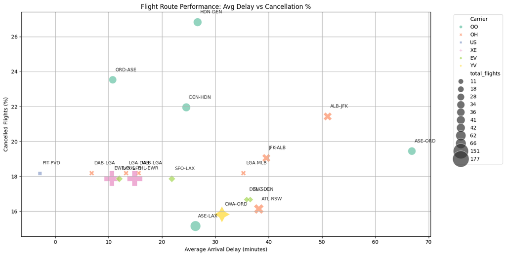

```python
top_bubble = route_perf.sort_values(by='cancelled_pct', ascending=False).head(20)

plt.figure(figsize=(12,7))
sns.scatterplot(
    data=top_bubble,
    x='avg_delay',
    y='cancelled_pct',
    size='total_flights',
    hue='Carrier',
    style='Carrier',
    palette='Set2',
    sizes=(100, 1000),  # bubble size range
    alpha=0.7,
    legend='full'
)
for i in range(top_bubble.shape[0]):
    route = top_bubble.iloc[i]
    plt.text(route['avg_delay'] + 0.5, route['cancelled_pct'] + 0.5, route['Route'],
             fontsize=9, alpha=0.8)

plt.title('Flight Route Performance: Avg Delay vs Cancellation %')
plt.xlabel('Average Arrival Delay (minutes)')
plt.ylabel('Cancelled Flights (%)')
plt.grid(True)
plt.tight_layout()
plt.legend(bbox_to_anchor=(1.05, 1), loc='upper left')
plt.show()
```

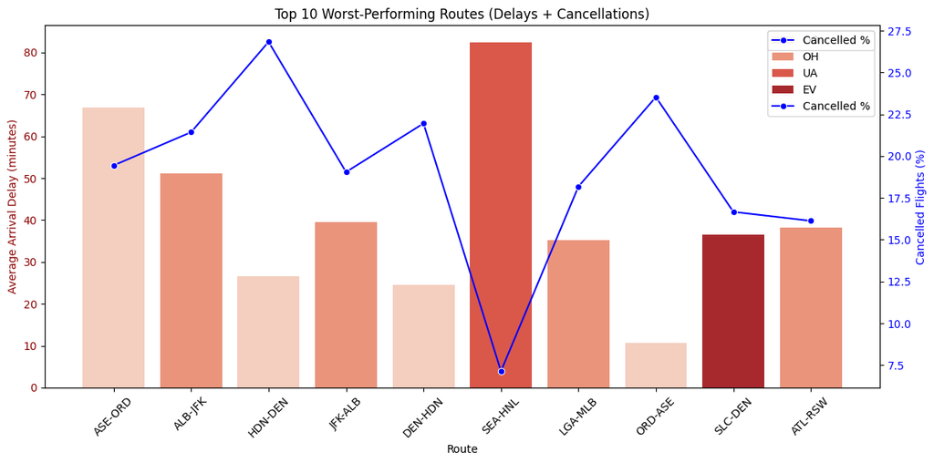

[output not shown]

```python
df = pd.read_csv('/content/output_q4_route_flight_perf.csv', header=None,
                 names=['Origin', 'Dest', 'Carrier', 'FlightNum', 'ArrDelay', 'Cancelled'])

df['ArrDelay'] = pd.to_numeric(df['ArrDelay'], errors='coerce')
df['Cancelled'] = pd.to_numeric(df['Cancelled'], errors='coerce')
df.dropna(subset=['Cancelled'], inplace=True)
df['Cancelled'] = df['Cancelled'].astype(int)

df.loc[(df['Cancelled'] == 1) & (df['ArrDelay'].isna()), 'ArrDelay'] = 0
df = df[~df['ArrDelay'].isna()]
df['ArrDelay'] = df['ArrDelay'].astype(int)

df['Route'] = df['Origin'] + '-' + df['Dest']

route_perf = df.groupby(['Route', 'Carrier']).agg(
    total_flights=('FlightNum', 'count'),
    avg_delay=('ArrDelay', 'mean'),
    total_cancelled=('Cancelled', 'sum')
).reset_index()

route_perf['cancelled_pct'] = (route_perf['total_cancelled'] / route_perf['total_flights']) * 100
route_perf = route_perf[route_perf['total_flights'] >= 10]
route_perf['scaled_delay'] = (route_perf['avg_delay'] - route_perf['avg_delay'].min()) / (route_perf['avg_delay'].max() - route_perf['avg_delay'].min())
route_perf['scaled_cancel'] = (route_perf['cancelled_pct'] - route_perf['cancelled_pct'].min()) / (route_perf['cancelled_pct'].max() - route_perf['cancelled_pct'].min())
route_perf['performance_score'] = (route_perf['scaled_delay'] + route_perf['scaled_cancel']) / 2

top_routes = route_perf.sort_values(by='performance_score', ascending=False).head(10)

# Plot
fig, ax1 = plt.subplots(figsize=(12,6))
sns.barplot(data=top_routes, x='Route', y='avg_delay', hue='Carrier', dodge=False, ax=ax1, palette='Reds')
ax1.set_ylabel('Average Arrival Delay (minutes)', color='darkred')
ax1.set_xlabel('Route')
ax1.set_title('Top 10 Worst-Performing Routes (Delays + Cancellations)')
ax1.tick_params(axis='x', rotation=45)
ax1.tick_params(axis='y', labelcolor='darkred')
ax2 = ax1.twinx()
sns.lineplot(data=top_routes, x='Route', y='cancelled_pct', color='blue', marker='o', ax=ax2, label='Cancelled %')
ax2.set_ylabel('Cancelled Flights (%)', color='blue')
ax2.tick_params(axis='y', labelcolor='blue')
h1, l1 = ax1.get_legend_handles_labels()
h2, l2 = ax2.get_legend_handles_labels()
ax1.legend(h1 + h2, l1 + l2, loc='upper right')
plt.tight_layout()
plt.show()
```

From the plot, some routes and carriers stand out for having both long delays and high cancellation rates. The route from ASE to ORD by OO has an average delay of about 67 minutes and almost 20 percent of flights cancelled. This suggests the problem happens often, not just once in a while.

Routes between ALB and JFK, both going and coming back, are also in the list. Both are operated by OH, with delays between 39 and 51 minutes and cancellation rates close to 20 percent. Since both directions are affected, it looks like this route regularly faces issues.

HDN to DEN and the return flight, also by OO, have lower delays but very high cancellations. For example, HDN to DEN has a cancellation rate of nearly 27 percent. This shows the route has frequent disruptions even if the delays are not that long.

ORD to ASE and DEN to HDN are also in the top ten. Most of these routes are run by regional airlines like OO and OH, and many of them face similar problems.

SEA to HNL by UA has the highest average delay, over 82 minutes, but only around 7 percent of flights are cancelled. This means flights on that route often run late but still operate.

The plot shows high red bars for average delay and high blue dots for cancellation. These top ten routes have the worst mix of delays and cancellations among all others.

## 4.2 Analyse the reasons these particular flights are prone to delays or cancellations.

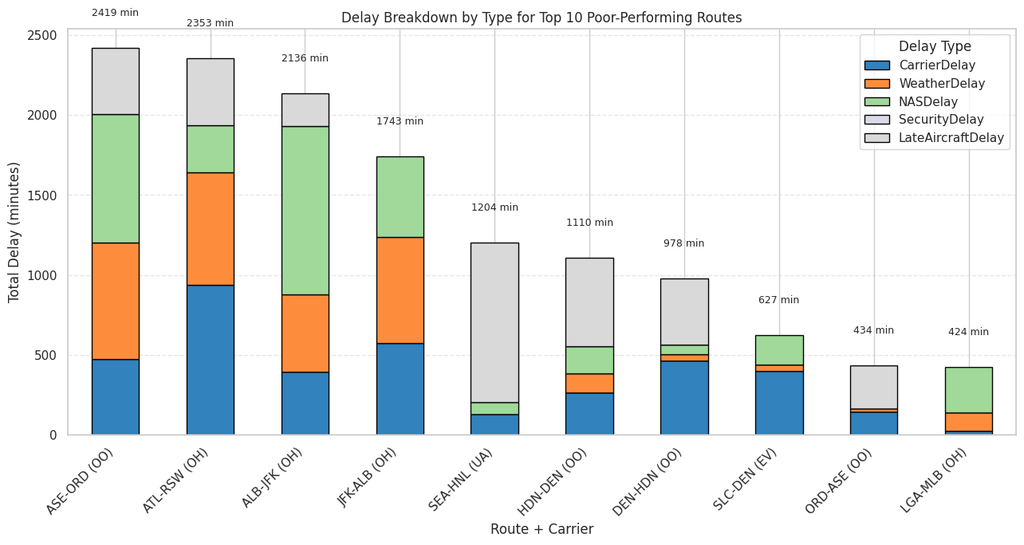

```python
df = pd.read_csv('/content/q44_delay_reason_perf_all.csv', names=[
    'Origin', 'Dest', 'Carrier', 'FlightNum', 'ArrDelay', 'Cancelled',
    'CarrierDelay', 'WeatherDelay', 'NASDelay', 'SecurityDelay',
    'LateAircraftDelay', 'CancellationCode'
])
df['Route'] = df['Origin'] + '-' + df['Dest']
df['RouteCarrier'] = df['Route'] + ' (' + df['Carrier'] + ')'

top_10_routes = [
    ('ASE-ORD', 'OO'),
    ('ALB-JFK', 'OH'),
    ('HDN-DEN', 'OO'),
    ('JFK-ALB', 'OH'),
    ('DEN-HDN', 'OO'),
    ('SEA-HNL', 'UA'),
    ('LGA-MLB', 'OH'),
    ('ORD-ASE', 'OO'),
    ('SLC-DEN', 'EV'),
    ('ATL-RSW', 'OH')
]
df_top = df[df.apply(lambda row: (row['Route'], row['Carrier']) in top_10_routes, axis=1)].copy()
delay_cols = ['CarrierDelay', 'WeatherDelay', 'NASDelay', 'SecurityDelay', 'LateAircraftDelay']
for col in delay_cols:
    df_top[col] = pd.to_numeric(df_top[col], errors='coerce').fillna(0).astype(int)

delay_sum = df_top.groupby('RouteCarrier')[delay_cols].sum()

delay_sum['TotalDelay'] = delay_sum.sum(axis=1)
delay_sum = delay_sum.sort_values(by='TotalDelay', ascending=False)

fig, ax = plt.subplots(figsize=(13, 7))
delay_sum.drop(columns='TotalDelay').plot(kind='bar', stacked=True, ax=ax,
                                          colormap='tab20c', edgecolor='black')
for i, total in enumerate(delay_sum['TotalDelay']):
    ax.text(i, total + 200, f'{int(total)} min', ha='center', fontsize=9)

ax.set_title('Delay Breakdown by Type for Top 10 Poor-Performing Routes')
ax.set_ylabel('Total Delay (minutes)')
ax.set_xlabel('Route + Carrier')
plt.xticks(rotation=45, ha='right')
plt.tight_layout()
plt.legend(title='Delay Type')
plt.grid(axis='y', linestyle='--', alpha=0.5)
plt.show()
```

SEA to HNL by UA has its delay mostly from late aircraft, likely due to inbound flight disruptions or tight turnaround schedules rather than real-time issues on that route. HDN to DEN and the reverse trip also show recurring delays from carrier and aircraft-related factors, pointing to repeated inefficiencies in scheduling or aircraft readiness.